# Analyzing Health, Economy, and Storms in the United States

Maria Feiler

8/23/2020

# Synopsis

The goal of this report is to explore the NOAA Storm Database to answer some basic questions about severe weather events and their consequences to health and the economy. This report aims to answer the following questions: 1. Across the United States, which types of events are most harmful with respect to population health? 2. Across the United States, which types of events have the greatest economic consequences?

# Introduction

Storms and other severe weather events can cause both public health and economic problems for communities and municipalities. Many severe events can result in fatalities, injuries, and property damage, and preventing such outcomes to the extent possible is a key concern.

This project involves exploring the U.S. National Oceanic and Atmospheric Administration’s (NOAA) storm database. This database tracks characteristics of major storms and weather events in the United States, including when and where they occur, as well as estimates of any fatalities, injuries, and property damage.

# Data

The stormData for this assignment come in the form of a comma-separated-value file compressed via the bzip2 algorithm to reduce its size. You can download the file from the course web site. There is also some documentation of the Database available. Here you will find how some of the variables are constructed/defined.

- [Storm Data](https://d396qusza40orc.cloudfront.net/repstormData%2FstormData%2FStormstormData.csv.bz2)
- [National Weather Service Storm Data Documentation](https://d396qusza40orc.cloudfront.net/repstormData%2Fpeer2_doc%2Fpd01016005curr.pdf)
- [National Climatic stormData Center Storm Events FAQ](https://d396qusza40orc.cloudfront.net/repstormData%2Fpeer2_doc%2FNCDC%20Storm%20Events-FAQ%20Page.pdf)

The events in the Database start in the year 1950 and end in November 2011. In the earlier years of the Database there are generally fewer events recorded, most likely due to a lack of good records. More recent years should be considered more complete.

# Data Processing

Set the working directory, download the file, and read the data into a dataframe.

```r
setwd(".")
download.file("https://d396qusza40orc.cloudfront.net/repdata%2Fdata%2FStormData.csv.bz2",destfile = "./stormData.csv.bz2",method = "curl")
stormData <- read.csv("./stormData.csv.bz2")
```

Investigate the dataframe to ensure proper transfer using the resources provided above.

```r
str(stormData)
```

```
## 'data.frame':    902297 obs. of  37 variables:
##  $ STATE__   : num  1 1 1 1 1 1 1 1 1 1 ...
##  $ BGN_DATE  : chr  "4/18/1950 0:00:00" "4/18/1950 0:00:00" "2/20/1951 0:00:00" "6/8/1951 0:00:00" ...
##  $ BGN_TIME  : chr  "0130" "0145" "1600" "0900" ...
##  $ TIME_ZONE : chr  "CST" "CST" "CST" "CST" ...
##  $ COUNTY    : num  97 3 57 89 43 77 9 123 125 57 ...
##  $ COUNTYNAME: chr  "MOBILE" "BALDWIN" "FAYETTE" "MADISON" ...
##  $ STATE     : chr  "AL" "AL" "AL" "AL" ...
##  $ EVTYPE    : chr  "TORNADO" "TORNADO" "TORNADO" "TORNADO" ...
##  $ BGN_RANGE : num  0 0 0 0 0 0 0 0 0 0 ...
##  $ BGN_AZI   : chr  "" "" "" "" ...
##  $ BGN_LOCATI: chr  "" "" "" "" ...
##  $ END_DATE  : chr  "" "" "" "" ...
##  $ END_TIME  : chr  "" "" "" "" ...
##  $ COUNTY_END: num  0 0 0 0 0 0 0 0 0 0 ...
```

[output cut: 23 more lines]

# Calculations and Transformations

Load the required packages.

```r
library(plyr)
library(ggplot2)
```

## Human Harm

Find the sum of FATALITIES and INJURIES by EVTYPE to help summarize the total harm done to humans based on event type. Then identify the top 10 harmful storm types.

```r
stormInjuries <- ddply(stormData, .(EVTYPE), summarize, TotalHarm = sum(FATALITIES + INJURIES))
stormInjuries <- stormInjuries[order(stormInjuries$TotalHarm, decreasing = T), ]
TopHarm <- stormInjuries[1:10,]
```

## Economic Harm

Find the sum of PROPDMG by EVTYPE and PROPDMGEXP to investigate the types and ammount of property damage by event type.

```r
damageProp <- ddply(stormData, .(EVTYPE, PROPDMGEXP), summarize, PROPDMG = sum(PROPDMG))
damageProp <- mutate(damageProp, PropertyDamage = ifelse(toupper(PROPDMGEXP) =='K', PROPDMG*1000, ifelse(toupper(PROPDMGEXP) =='M', PROPDMG*1000000, ifelse(toupper(PROPDMGEXP) == 'B', PROPDMG*1000000000, ifelse(toupper(PROPDMGEXP) == 'H', PROPDMG*100, PROPDMG)))))
damageProp <- subset(damageProp, select = c("EVTYPE", "PropertyDamage"))
damagePropTotal <- ddply(damageProp, .(EVTYPE), summarize, TotalPropDamage = sum(PropertyDamage))
```

Find the sum of CROPDMG by EVTYPE and CROPDMGEXP to investigate the types and ammount of crop damage by event type.

```r
damageCrop <- ddply(stormData, .(EVTYPE, CROPDMGEXP), summarize, CROPDMG = sum(CROPDMG))
damageCrop <- mutate(damageCrop, CropDamage = ifelse(toupper(CROPDMGEXP) =='K', CROPDMG*1000, ifelse(toupper(CROPDMGEXP) =='M', CROPDMG*1000000, ifelse(toupper(CROPDMGEXP) == 'B', CROPDMG*1000000000, ifelse(toupper(CROPDMGEXP) == 'H', CROPDMG*100, CROPDMG)))))
damageCrop <- subset(damageCrop, select = c("EVTYPE", "CropDamage"))
damageCropTotal <- ddply(damageCrop, .(EVTYPE), summarize, TotalCropDamage = sum(CropDamage))
```

Combine the property and crop damage to investigate total damage done by storm type. Then identify the top 10 harmful storm types.

```r
stormDamage <- merge(damagePropTotal, damageCropTotal, by="EVTYPE")
stormDamage <- mutate(stormDamage, TotalDamage = TotalPropDamage + TotalCropDamage)
stormDamage <- stormDamage[order(stormDamage$TotalDamage, decreasing = T), ]
TopDamage <- stormDamage[1:10, ]
```

# Results

## Population Health and Storm Events

Based on the data presented below, tornadoes cause the most injury and fatalities, or harm to population health, in the United States.

```r
TopHarm
```

```
##                EVTYPE TotalHarm
## 834           TORNADO     96979
## 130    EXCESSIVE HEAT      8428
## 856         TSTM WIND      7461
## 170             FLOOD      7259
## 464         LIGHTNING      6046
## 275              HEAT      3037
## 153       FLASH FLOOD      2755
## 427         ICE STORM      2064
## 760 THUNDERSTORM WIND      1621
## 972      WINTER STORM      1527
```

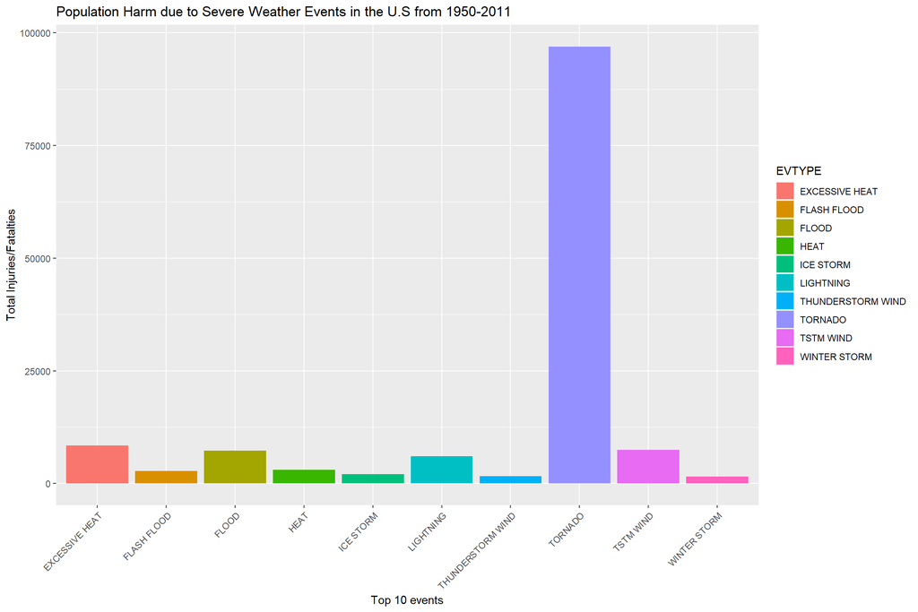

```r
totalHarmPlot <- ggplot(TopHarm, aes(EVTYPE,TotalHarm, fill=EVTYPE)) + geom_bar(stat="identity") + xlab("Top 10 events")+ ylab("Total Injuries/Fatalties")+ ggtitle("Population Harm due to Severe Weather Events in the U.S from 1950-2011") + theme(axis.text.x=element_text(angle=45,hjust=1))
totalHarmPlot
```

## Economic Damage and Storm Events

Based on the data presented below, foods cause the most property and crop damage, or negative economic impact, in the United States.

```r
TopDamage
```

```
##                EVTYPE TotalPropDamage TotalCropDamage  TotalDamage
## 170             FLOOD    144657709807      5661968450 150319678257
## 411 HURRICANE/TYPHOON     69305840000      2607872800  71913712800
## 834           TORNADO     56937160779       414953270  57352114049
## 670       STORM SURGE     43323536000            5000  43323541000
## 244              HAIL     15732267543      3025954473  18758222016
## 153       FLASH FLOOD     16140812067      1421317100  17562129167
## 95            DROUGHT      1046106000     13972566000  15018672000
## 402         HURRICANE     11868319010      2741910000  14610229010
## 590       RIVER FLOOD      5118945500      5029459000  10148404500
## 427         ICE STORM      3944927860      5022113500   8967041360
```

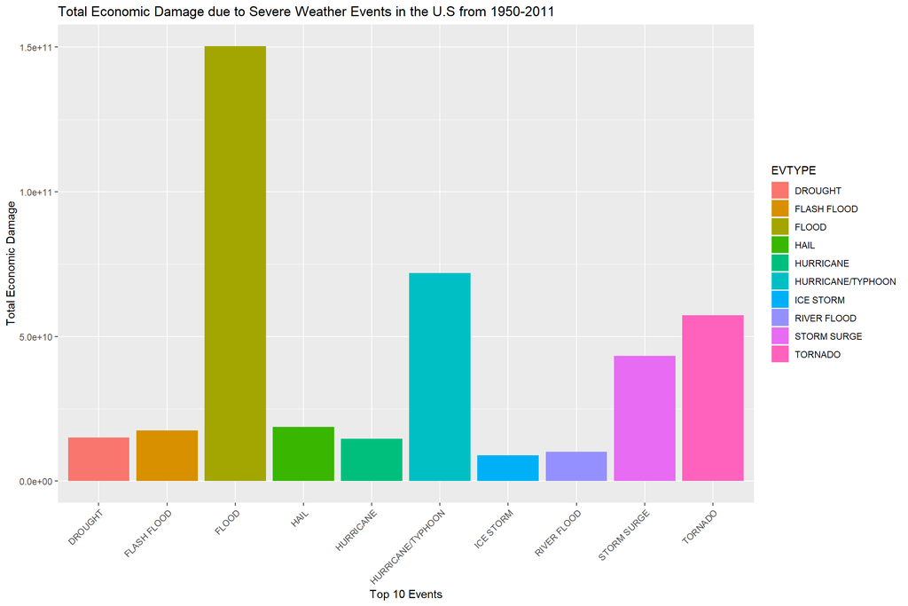

```r
totalDamagePlot <- ggplot(TopDamage, aes(EVTYPE,TotalDamage, fill=EVTYPE)) + geom_bar(stat="identity") + xlab("Top 10 Events")+ ylab("Total Economic Damage")+ ggtitle("Total Economic Damage due to Severe Weather Events in the U.S from 1950-2011") + theme(axis.text.x=element_text(angle=45,hjust=1))
totalDamagePlot
```

# Conclusions

Overall, tornados represent the most risk to population health while floods represent the highest risk for property damage. Resources should be distributed accordingly.